# UC business Analytics R programming Guide

### 2.1.7 Multivariate Adaptive regression splines (MARS)

This tutorial discusses multivariate adaptive regression splines (MARS), an algorithm that essentially creates a piecewise linear model which provides an intuitive stepping block into nonlinearity after grasping the concept of linear regression and other intrinsically linear models.

- Prerequisites
- Multivariage regression splines
- Fitting a basic MARS model

#### 2.1.7.1 Prerequisites

For this tutorial we will use the following packages:

```r
library(rsample)   # data splitting
library(ggplot2)   # plotting
library(earth)     # fit MARS models
library(caret)     # automating the tuning process
library(vip)       # variable importance
library(pdp)       # variable relationships
```

To illustrate various MARS modeling concepts we will use `Ames Housing` data, which is available via the `AmesHousing` package.

```r
# Create training (70%) and test (30%) sets for the AmesHousing::make_ames() data.
# Use set.seed for reproducibility

set.seed(123)
ames_split <- initial_split(AmesHousing::make_ames(), prop = .7, strata = "Sale_Price")
ames_train <- training(ames_split)
ames_test  <- testing(ames_split)
```

#### 2.1.7.2 The basic idea

Some previous tutorials have focused on linear models. In those tutorials we illustrated some of the advantages of linear models such as their ease and speed of computation and also the intuitive nature of interpreting their coefficients. However, linear models make a strong assumption about linearity, and this assumption is often a poor one, which can affect predictive accuracy.

We can extend linear models to capture non-linear relationships. Typically, this is done by explicitly including polynomial parameters or step functions. Polynomial regression is a form of regression in which the relationship between the independent variable $x$ and the dependent variable y is modeled as an $n^{th}$ degree polynomial of $x$. For example, Equation 1 represents a polynomial regression function where y is modeled as a function of $x$ with $d$ degrees. Generally speaking, it is unusual to use d greater than 3 or 4 as the larger d becomes, the easier the function fit becomes overly flexible and oddly shapened…especially near the boundaries of the range of x values

$$y_i = \beta_0 + \beta_1x_i + \beta_2x_i^2+...+\beta_dx_i^d+\epsilon_i$$

An alternative to polynomial regression. is step function regression. Whereas polynomial functions impose a global non-linear relationship, step functions break the range of $x$ into bins, and fit a different constant for each bin. This amounts to converting a continuous variable into an ordered categorical variable such that our linear regression function is converted to Equation 2

$$y_i = \beta_0 + \beta_1 C_1(x_i) + \beta_2 C_2(x_i) + ... + \beta_d C_d(x_i) + \epsilon_i$$

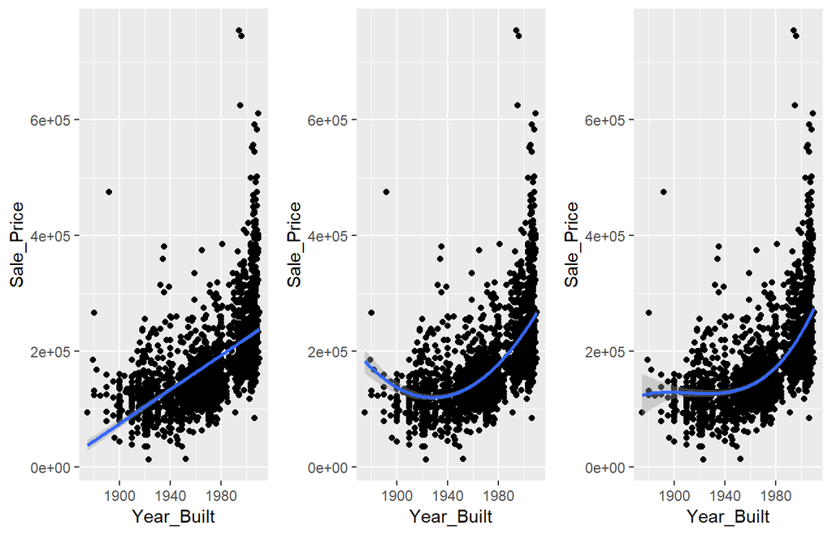

```r
# polynomial degree of 1
p1 <- ames_train %>%
  ggplot(aes(Year_Built, Sale_Price))+
  geom_point()+
  geom_smooth(method = "gam", formula = y ~ x)

# polynomial degree of 2
p2 <- ames_train %>%
  ggplot(aes(Year_Built, Sale_Price))+
  geom_point()+
  geom_smooth(method = "gam", formula = y ~ poly(x,2))

# polynomial degree of 3
p3 <- ames_train %>%
  ggplot(aes(Year_Built, Sale_Price))+
  geom_point()+
  geom_smooth(method = "gam", formula = y ~ poly(x,3))

# step function

gridExtra::grid.arrange(p1, p2, p3, ncol=3)
```

Although useful, the typical implementation of polynomial regression and step functions require the user to explicitly identify and incorporate which variables should have what specific degree of interaction or at points of a variable $x$ should cut points to be made for the step functions. Considering many data sets today can easily contain 50, 100, or more features, this would require an enormous and unncessary time commitment from an analyst to determine these explicit non-linear settings.

#### 2.1.7.3 Multivariage regression splines

Multivariate adaptive regression splines (MARS) provide a convenient approach to capture the nonlinearity aspect of polynomial regression by assessing cutpoints ( *knots*) similar to step functions. The procedure assesses each data point for each predictor as a knot and creates a linear regression model with the candidate feature(s). For example, consider our simple model of `Sale_Price` ~ `Year_Built`. The MARS procedure will first look for the single point across the range of Year_Built values where two different linear relationships between `Sale_Price` and `Year_Built` achieve the smallest error.

What results is known as hinge function ($h(x-a)$ where $a$ is the cutpoint value). For a single knot, our hinge function is $h(Year_Built - 1968$ such that our two linear models for `Sale_Price` are

$$Sale\_Price = 136091.022 (for \ Year\_Built < 1968)
136091.022 + 3094.208 (Year\_Built-1968) (for Year\_Built > 1968)$$

```r
mars0 <- ames_train %>%
  earth::earth(Sale_Price ~ Year_Built, data=.)

mars0 %>% print()
```

[output not shown]

Consequently, once the full set of knots have been created, we can sequentially remove knots that do not contribute significantly to predictive accuracy. This process is known as “pruning” and we can use cross-validation, as we have with the previous models, to find the optimal number of knot

#### 2.1.7.4 Fitting a basic MARS model

We can fit a MARS model with the **earth** package. By default, `earth::earth()` will assess all potential knots across all supplied features and then will prune to the optimal number of knots on an expected change in $R^2$ (for the training data) of less than 0.001. This calculation is performed by the Generalized cross-validation procedure (GCV statistic), which is a computational shortcut for linear models that produces an error value that approximates leave-one-out cross-validation (see [here](http://w3.atomki.hu/~efo/hornyak/Tikhonov_references/Technometrics_Golub_Heath_Wahba) for technical details).

The following applies a basic MARS model to our ames data and performs a search for required knots across all features. The results show us the final models GCV statistic, generalized $R^2$ (GRSq) and more.

```r
# Fit a basic MARS model
mars1 <- earth::earth(
  Sale_Price ~.,
  data = ames_train
)

# Print model summary
print(mars1)
## Selected 37 of 45 terms, and 26 of 307 predictors
## Termination condition: RSq changed by less than 0.001 at 45 terms
## Importance: Gr_Liv_Area, Year_Built, Total_Bsmt_SF, ...
## Number of terms at each degree of interaction: 1 36 (additive model)
## GCV 521186626    RSS 995776275391    GRSq 0.9165386    RSq 0.92229
## Selected 37 of 45 terms, and 26 of 307 predictors
## Termination condition: RSq changed by less than 0.001 at 45 terms
## Importance: Gr_Liv_Area, Year_Built, Total_Bsmt_SF, ...
## Number of terms at each degree of interaction: 1 36 (additive model)
## GCV 521186626    RSS 995776275391    GRSq 0.9165386    RSq 0.92229
```

### 2.1.8 Regression trees & bagging

### 2.1.9 Random forests

### 2.1.10 Gradient boosting machines (GBM)

## 2.2 Resampling methods

### 2.2.1 Resampling basics